# Fraudulent job postings

Due to the large amount of modules imported, we have made a duplicate Google Colab notebook [here](https://colab.research.google.com/drive/1tkvBHFZKgjELibboshSUl6sEP_rT4fTI?usp=sharing) for ease of running this notebook.

### Our objectives and the questions we intend to answer:

- Identify fake job postings by sentiment analysis.
- Which model is the best, in terms of metric scores, memory used and speed?
- Identify countries which are associated with fraud postings.
- Find associated features with a fraudulent and non-fraudulent posting.

> Our conclusions and takeaways are located at the end of this notebook.

*This project was submitted as part of the requirements of* *EE0005 Introduction to Data Science and Artificial Intelligence.*

# NLP pipeline

For Natural Language Processing (NLP), we have a slightly different pipeline compared to a numerical/category dataset as per below.  
*Image source: https://mlwhiz.com/images/text_processing_flow_1.png*

[figure not shown]

For our case, we use token counts with a TF-IDF Vectoriser for our `scikit-learn` models and word embeddings for our `Tensorflow` models.

### The list of contributors for this project is tabled below.

| Name (Alphabetical Order) | Contributions |
| --- | --- |
| Goh Lee Hua | Text pre-processing, Random forest classifier and GridSearchCV, Markdown comments |
| Hansel Tay | Lemmatization, Metrics, Oversampling and undersampling techniques |
| Philip Lee Hann Yung | Feature extraction, TF-IDF vectorization, Modelling and Hyperparameter tuning, Organization of project pipeline, Markdown comments |
| Tan Keng Soon | Visualisation, Exploratory data analysis (EDA) |

# Google Colab environment

The datasets are hosted on Philip's GitHub for downloading convenience.  
*Only run the code below if you are on Google Colab.*

```python
# !wget https://leephilipx.github.io/EE0005/fake_job_postings.csv
# !wget https://leephilipx.github.io/EE0005/fake_job_postings_lemmatized.csv
# # %load_ext google.colab.data_table
```

```
--2020-11-12 16:34:15--  https://leephilipx.github.io/EE0005/fake_job_postings.csv
Resolving leephilipx.github.io (leephilipx.github.io)... 185.199.108.153, 185.199.109.153, 185.199.110.153, ...
Connecting to leephilipx.github.io (leephilipx.github.io)|185.199.108.153|:443... connected.
HTTP request sent, awaiting response... 200 OK
Length: 50043721 (48M) [text/csv]
Saving to: ‘fake_job_postings.csv’

fake_job_postings.c 100%[===================>]  47.72M  90.3MB/s    in 0.5s

2020-11-12 16:34:16 (90.3 MB/s) - ‘fake_job_postings.csv’ saved [50043721/50043721]

--2020-11-12 16:34:16--  https://leephilipx.github.io/EE0005/fake_job_postings_lemmatized.csv
Resolving leephilipx.github.io (leephilipx.github.io)... 185.199.108.153, 185.199.109.153, 185.199.110.153, ...
Connecting to leephilipx.github.io (leephilipx.github.io)|185.199.108.153|:443... connected.
HTTP request sent, awaiting response... 200 OK
Length: 38390431 (37M) [text/csv]
Saving to: ‘fake_job_postings_lemmatized.csv’

fake_job_postings_l 100%[===================>]  36.61M  50.5MB/s    in 0.7s

2020-11-12 16:34:17 (50.5 MB/s) - ‘fake_job_postings_lemmatized.csv’ saved [38390431/38390431]
```

```python
# ## This code is so that Google Colab prints with word wrap
# from IPython.display import HTML, display
# def set_css():
#     display(HTML('''<style>pre {white-space: pre-wrap;}</style>'''))
# get_ipython().events.register('pre_run_cell', set_css)
```

# Import relevant modules and dataset

The dataset is sourced from https://www.kaggle.com/shivamb/real-or-fake-fake-jobposting-prediction

```python
# Essential data science modules
import pandas as pd
import numpy as np
import matplotlib.pyplot as plt
import seaborn as sb
sb.set()

# Natural Language Toolkit (NTLK) modules
import nltk
from nltk import pos_tag
from nltk.stem import WordNetLemmatizer
from nltk.corpus import stopwords, wordnet
nltk.download(['stopwords', 'averaged_perceptron_tagger', 'wordnet', 'punkt'])

# scikit-learn modules
from sklearn.model_selection import train_test_split, GridSearchCV
from sklearn.dummy import DummyClassifier
from sklearn.feature_extraction.text import CountVectorizer, TfidfVectorizer
from sklearn.preprocessing import LabelEncoder
from sklearn.metrics import accuracy_score, roc_auc_score, matthews_corrcoef, confusion_matrix
from sklearn.metrics import classification_report, f1_score, fbeta_score
from sklearn.metrics import plot_roc_curve
from sklearn.linear_model import LogisticRegression
from sklearn.naive_bayes import MultinomialNB, BernoulliNB
from sklearn.svm import SVC
from sklearn.ensemble import RandomForestClassifier

# Other modules
!pip install stop_words eli5
from stop_words import get_stop_words
import eli5
import re
from scipy import stats
import matplotlib.gridspec as gridspec
from wordcloud import WordCloud
from imblearn.under_sampling import RandomUnderSampler
from imblearn.over_sampling import SMOTE, BorderlineSMOTE, SVMSMOTE, ADASYN
from imblearn.pipeline import Pipeline
import plotly.graph_objects as go
from plotly.subplots import make_subplots
import spacy
from spacy.lang.en import English
import gc
import tensorflow as tf
from tensorflow import keras
from tensorflow.keras.preprocessing.sequence import pad_sequences
from tensorflow.keras.preprocessing.text import Tokenizer
```

```
     |████████████████████████████████| 112kB 8.3MB/s
```

```python
df = pd.read_csv('fake_job_postings.csv')
df.head(5)
```

|  | job_id | title | location | department | salary_range | company_profile | description | requirements | benefits | telecommuting | has_company_logo | has_questions | employment_type | required_experience | required_education | industry | function | fraudulent |
| --- | --- | --- | --- | --- | --- | --- | --- | --- | --- | --- | --- | --- | --- | --- | --- | --- | --- | --- |
| 0 | 1 | Marketing Intern | US, NY, New York | Marketing | NaN | We're Food52, and we've created a groundbreaki... | Food52, a fast-growing, James Beard Award-winn... | Experience with content management systems a m... | NaN | 0 | 1 | 0 | Other | Internship | NaN | NaN | Marketing | 0 |
| 1 | 2 | Customer Service - Cloud Video Production | NZ, , Auckland | Success | NaN | 90 Seconds, the worlds Cloud Video Production ... | Organised - Focused - Vibrant - Awesome!Do you... | What we expect from you:Your key responsibilit... | What you will get from usThrough being part of... | 0 | 1 | 0 | Full-time | Not Applicable | NaN | Marketing and Advertising | Customer Service | 0 |
| 2 | 3 | Commissioning Machinery Assistant (CMA) | US, IA, Wever | NaN | NaN | Valor Services provides Workforce Solutions th... | Our client, located in Houston, is actively se... | Implement pre-commissioning and commissioning ... | NaN | 0 | 1 | 0 | NaN | NaN | NaN | NaN | NaN | 0 |
| 3 | 4 | Account Executive - Washington DC | US, DC, Washington | Sales | NaN | Our passion for improving quality of life thro... | THE COMPANY: ESRI – Environmental Systems Rese... | EDUCATION: Bachelor’s or Master’s in GIS, busi... | Our culture is anything but corporate—we have ... | 0 | 1 | 0 | Full-time | Mid-Senior level | Bachelor's Degree | Computer Software | Sales | 0 |
| 4 | 5 | Bill Review Manager | US, FL, Fort Worth | NaN | NaN | SpotSource Solutions LLC is a Global Human Cap... | JOB TITLE: Itemization Review ManagerLOCATION:... | QUALIFICATIONS:RN license in the State of Texa... | Full Benefits Offered | 0 | 1 | 1 | Full-time | Mid-Senior level | Bachelor's Degree | Hospital & Health Care | Health Care Provider | 0 |

# Exploratory data analysis (EDA)

Some pre-processing is done in this portion namely:

- Feature extraction on the presence of the text fields `company_profile`, `description`, `requirements` and `benefits`
- Splitting of `location` to 3 columns - country, state and city

```python
bin_features = ['telecommuting', 'has_company_logo', 'has_questions']
cat_features = ['department', 'employment_type', 'required_experience',
                'required_education', 'industry', 'function']

text_features = ['title', 'company_profile', 'description', 'requirements', 'benefits']
complex_features = ['location', 'salary_range']

for feature_name in text_features[1:]:
    unspec_feature_name = f'{feature_name}_specified'
    df[unspec_feature_name] = (~df[feature_name].isna()).astype('int')
    bin_features += [unspec_feature_name]

df.head()[text_features + bin_features[-4:]]
```

|  | title | company_profile | description | requirements | benefits | company_profile_specified | description_specified | requirements_specified | benefits_specified |
| --- | --- | --- | --- | --- | --- | --- | --- | --- | --- |
| 0 | Marketing Intern | We're Food52, and we've created a groundbreaki... | Food52, a fast-growing, James Beard Award-winn... | Experience with content management systems a m... | NaN | 1 | 1 | 1 | 0 |
| 1 | Customer Service - Cloud Video Production | 90 Seconds, the worlds Cloud Video Production ... | Organised - Focused - Vibrant - Awesome!Do you... | What we expect from you:Your key responsibilit... | What you will get from usThrough being part of... | 1 | 1 | 1 | 1 |
| 2 | Commissioning Machinery Assistant (CMA) | Valor Services provides Workforce Solutions th... | Our client, located in Houston, is actively se... | Implement pre-commissioning and commissioning ... | NaN | 1 | 1 | 1 | 0 |
| 3 | Account Executive - Washington DC | Our passion for improving quality of life thro... | THE COMPANY: ESRI – Environmental Systems Rese... | EDUCATION: Bachelor’s or Master’s in GIS, busi... | Our culture is anything but corporate—we have ... | 1 | 1 | 1 | 1 |
| 4 | Bill Review Manager | SpotSource Solutions LLC is a Global Human Cap... | JOB TITLE: Itemization Review ManagerLOCATION:... | QUALIFICATIONS:RN license in the State of Texa... | Full Benefits Offered | 1 | 1 | 1 | 1 |

```python
# Split the locations into separate columns
location = df['location'].copy()
location_splitted = list(location.str.split(', ').values)

# Some locations are not lists so this code makes it uniform
location_splitted = list(map(lambda loc: loc if type(loc) is list else [loc], location_splitted))
location_splitted[:15]
```

```
[['US', 'NY', 'New York'],
 ['NZ', '', 'Auckland'],
 ['US', 'IA', 'Wever'],
 ['US', 'DC', 'Washington'],
 ['US', 'FL', 'Fort Worth'],
 ['US', 'MD', ''],
 ['DE', 'BE', 'Berlin'],
 ['US', 'CA', 'San Francisco'],
 ['US', 'FL', 'Pensacola'],
 ['US', 'AZ', 'Phoenix'],
 ['US', 'NJ', 'Jersey City'],
 ['GB', 'LND', 'London'],
 ['US', 'CT', 'Stamford'],
 ['US', 'FL', 'Orlando'],
 ['AU', 'NSW', 'Sydney']]
```

```python
for loc_ind, loc in enumerate(location_splitted):
    if loc is np.nan:
        location_splitted[loc_ind] = ['Unspecified'] * 3
    else:
        for el_ind, el in enumerate(loc):
            if el == '':
                loc[el_ind] = 'Unspecified'
```

```python
for loc_ind, loc in enumerate(location_splitted):
    if len(loc) > 3:
        location_splitted[loc_ind] = loc[:2] + [', '.join(loc[2:])]
    if len(loc) < 3:
        location_splitted[loc_ind] += ['Unspecified'] * 2

data_location = pd.DataFrame(location_splitted, columns=['country', 'state', 'city'])
data_location.head(15)
```

|  | country | state | city |
| --- | --- | --- | --- |
| 0 | US | NY | New York |
| 1 | NZ | Unspecified | Auckland |
| 2 | US | IA | Wever |
| 3 | US | DC | Washington |
| 4 | US | FL | Fort Worth |
| 5 | US | MD | Unspecified |
| 6 | DE | BE | Berlin |
| 7 | US | CA | San Francisco |
| 8 | US | FL | Pensacola |
| 9 | US | AZ | Phoenix |
| 10 | US | NJ | Jersey City |
| 11 | GB | LND | London |
| 12 | US | CT | Stamford |
| 13 | US | FL | Orlando |
| 14 | AU | NSW | Sydney |

```python
df = pd.concat([df, data_location], axis=1)
df.head()
```

|  | job_id | title | location | department | salary_range | company_profile | description | requirements | benefits | telecommuting | has_company_logo | has_questions | employment_type | required_experience | required_education | industry | function | fraudulent | company_profile_specified | description_specified | requirements_specified | benefits_specified | country | state | city |
| --- | --- | --- | --- | --- | --- | --- | --- | --- | --- | --- | --- | --- | --- | --- | --- | --- | --- | --- | --- | --- | --- | --- | --- | --- | --- |
| 0 | 1 | Marketing Intern | US, NY, New York | Marketing | NaN | We're Food52, and we've created a groundbreaki... | Food52, a fast-growing, James Beard Award-winn... | Experience with content management systems a m... | NaN | 0 | 1 | 0 | Other | Internship | NaN | NaN | Marketing | 0 | 1 | 1 | 1 | 0 | US | NY | New York |
| 1 | 2 | Customer Service - Cloud Video Production | NZ, , Auckland | Success | NaN | 90 Seconds, the worlds Cloud Video Production ... | Organised - Focused - Vibrant - Awesome!Do you... | What we expect from you:Your key responsibilit... | What you will get from usThrough being part of... | 0 | 1 | 0 | Full-time | Not Applicable | NaN | Marketing and Advertising | Customer Service | 0 | 1 | 1 | 1 | 1 | NZ | Unspecified | Auckland |
| 2 | 3 | Commissioning Machinery Assistant (CMA) | US, IA, Wever | NaN | NaN | Valor Services provides Workforce Solutions th... | Our client, located in Houston, is actively se... | Implement pre-commissioning and commissioning ... | NaN | 0 | 1 | 0 | NaN | NaN | NaN | NaN | NaN | 0 | 1 | 1 | 1 | 0 | US | IA | Wever |
| 3 | 4 | Account Executive - Washington DC | US, DC, Washington | Sales | NaN | Our passion for improving quality of life thro... | THE COMPANY: ESRI – Environmental Systems Rese... | EDUCATION: Bachelor’s or Master’s in GIS, busi... | Our culture is anything but corporate—we have ... | 0 | 1 | 0 | Full-time | Mid-Senior level | Bachelor's Degree | Computer Software | Sales | 0 | 1 | 1 | 1 | 1 | US | DC | Washington |
| 4 | 5 | Bill Review Manager | US, FL, Fort Worth | NaN | NaN | SpotSource Solutions LLC is a Global Human Cap... | JOB TITLE: Itemization Review ManagerLOCATION:... | QUALIFICATIONS:RN license in the State of Texa... | Full Benefits Offered | 0 | 1 | 1 | Full-time | Mid-Senior level | Bachelor's Degree | Hospital & Health Care | Health Care Provider | 0 | 1 | 1 | 1 | 1 | US | FL | Fort Worth |

## Overview of dataset

Some information about the dataset - most of them are text fields and categorical data.

```python
df.info()
```

```
<class 'pandas.core.frame.DataFrame'>
RangeIndex: 17880 entries, 0 to 17879
Data columns (total 25 columns):
 #   Column                     Non-Null Count  Dtype
---  ------                     --------------  -----
 0   job_id                     17880 non-null  int64
 1   title                      17880 non-null  object
 2   location                   17534 non-null  object
 3   department                 6333 non-null   object
 4   salary_range               2868 non-null   object
 5   company_profile            14572 non-null  object
 6   description                17879 non-null  object
 7   requirements               15185 non-null  object
 8   benefits                   10670 non-null  object
 9   telecommuting              17880 non-null  int64
```

[output cut: 17 more lines]

```python
# This description can be ignored as the data are all categorical data
df.describe()
```

|  | job_id | telecommuting | has_company_logo | has_questions | fraudulent | company_profile_specified | description_specified | requirements_specified | benefits_specified |
| --- | --- | --- | --- | --- | --- | --- | --- | --- | --- |
| count | 17880.000000 | 17880.000000 | 17880.000000 | 17880.000000 | 17880.000000 | 17880.000000 | 17880.000000 | 17880.000000 | 17880.000000 |
| mean | 8940.500000 | 0.042897 | 0.795302 | 0.491723 | 0.048434 | 0.814989 | 0.999944 | 0.849273 | 0.596756 |
| std | 5161.655742 | 0.202631 | 0.403492 | 0.499945 | 0.214688 | 0.388317 | 0.007479 | 0.357793 | 0.490563 |
| min | 1.000000 | 0.000000 | 0.000000 | 0.000000 | 0.000000 | 0.000000 | 0.000000 | 0.000000 | 0.000000 |
| 25% | 4470.750000 | 0.000000 | 1.000000 | 0.000000 | 0.000000 | 1.000000 | 1.000000 | 1.000000 | 0.000000 |
| 50% | 8940.500000 | 0.000000 | 1.000000 | 0.000000 | 0.000000 | 1.000000 | 1.000000 | 1.000000 | 1.000000 |
| 75% | 13410.250000 | 0.000000 | 1.000000 | 1.000000 | 0.000000 | 1.000000 | 1.000000 | 1.000000 | 1.000000 |
| max | 17880.000000 | 1.000000 | 1.000000 | 1.000000 | 1.000000 | 1.000000 | 1.000000 | 1.000000 | 1.000000 |

```python
temp = df
```

```python
drop_columns = ['job_id', 'title', 'location', 'department', 'industry', 'function']

proc_df = temp.drop(drop_columns, axis=1)

del temp
gc.collect()
```

```
12
```

```python
text_columns = ['company_profile', 'description', 'requirements', 'benefits']

proc_df = proc_df.dropna(subset=text_columns, how='all')

for col in text_columns:
    proc_df[col].fillna(' ', inplace=True)
```

```
Percentage of fraudulent job postings = 4.84 %
```

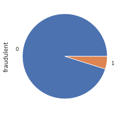

```python
# Calculate percentage of fraudulent job postings
rating_series = df['fraudulent'].value_counts()
print(f'Percentage of fraudulent job postings = {round(rating_series[1]/len(df)*100, 2)} %')
rating_series.plot(kind="pie");
```

## Distribution of fraudulent and non-fraudulent job postings

We also take a look at the distribution of text count in `company_profile`,`description`,`requirements`,`benefits` and found that all are about the same except for `company_profile`.

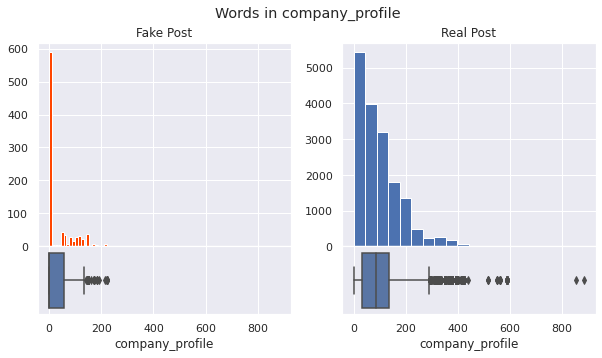

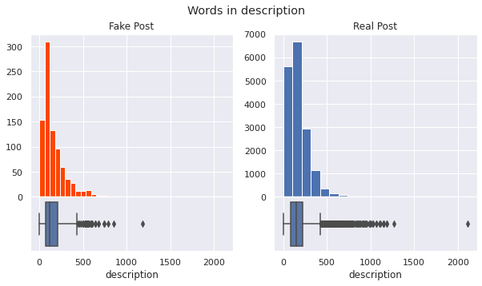

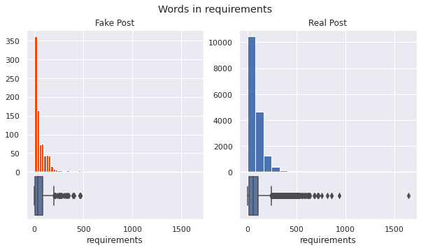

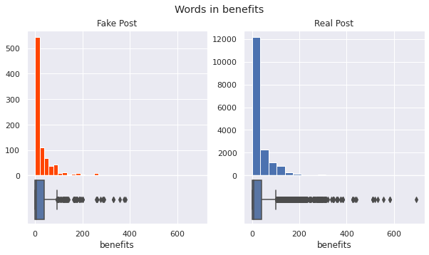

```python
text_cols = ['company_profile', 'description', 'requirements', 'benefits']

for col in text_cols:
    fig, ax = plt.subplots(2, 2, figsize=(10, 5), gridspec_kw={'height_ratios':[3,1]},sharex='row')
    num=proc_df[proc_df["fraudulent"]==1][col].str.split().map(lambda x: len(x))
    ax[0][0].hist(num,bins = 20,color='orangered')
    ax[0][0].set_title('Fake Post')
    ax[0][0].set_xticklabels('')
    sb.boxplot(x=num, orient='h', ax=ax[1][0])
    num=proc_df[proc_df["fraudulent"]==0][col].str.split().map(lambda x: len(x))
    ax[0][1].hist(num, bins = 20)
    ax[0][1].set_title('Real Post')
    sb.boxplot(x=num, orient='h', ax=ax[1][1])
    fig.suptitle(f'Words in {col}')
    plt.subplots_adjust(hspace=0)
    plt.show()
```

The visualisation below suggests that `has_company_logo = 0` and `company_profile_specified = 0` are good predictors that the jobs posting is fraudulent, which is what we hypothesize.

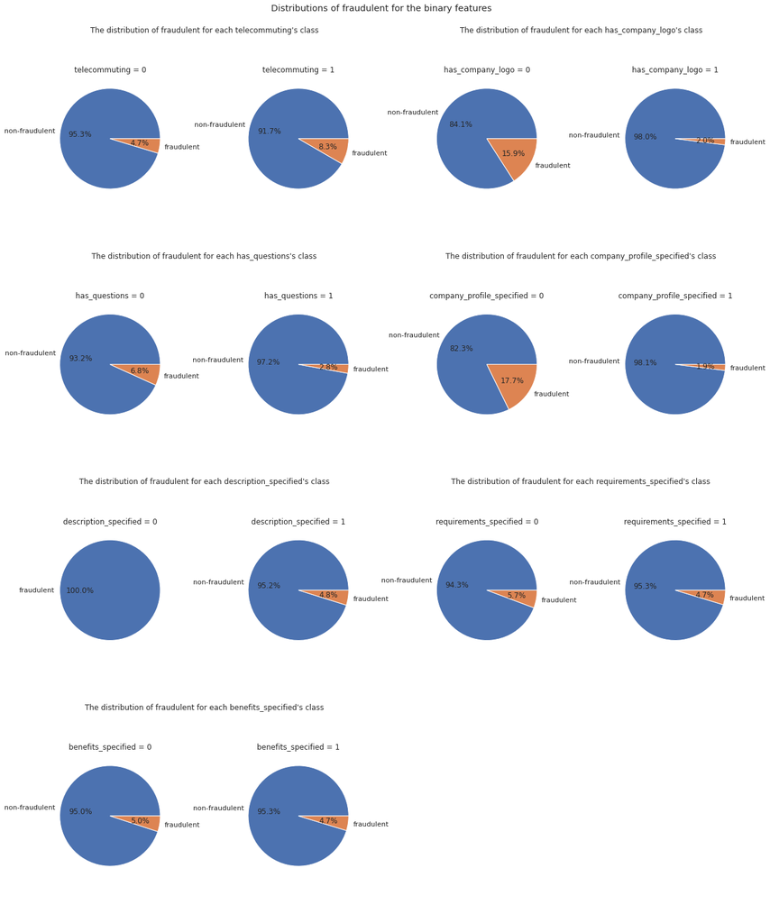

```python
fig = plt.figure(figsize=(20, 24))
outer = gridspec.GridSpec(4, 2, wspace=0.2, hspace=0.1)

for feature_ind, feature_name in enumerate(bin_features):
    inner = gridspec.GridSpecFromSubplotSpec(1, 2, subplot_spec=outer[feature_ind],
                                             wspace=0.5, hspace=0.2)

    ax = plt.Subplot(fig, outer[feature_ind])
    ax.set_title(f'The distribution of fraudulent for each {feature_name}\'s class')
    ax.axis('off')
    fig.add_subplot(ax)

    for feature_class in [0, 1]:
        ax = plt.Subplot(fig, inner[feature_class])
        feature_cl_vc = df[df[feature_name] == feature_class].fraudulent.value_counts().sort_index()
        if len(feature_cl_vc) == 2:
            feature_cl_vc.index = ['non-fraudulent', 'fraudulent']
        else:
            feature_cl_vc.index = ['fraudulent']

        ax.pie(feature_cl_vc.values, labels=feature_cl_vc.index, autopct='%1.1f%%')
        ax.set_title(f'{feature_name} = {feature_class}')
        fig.add_subplot(ax)

fig.suptitle('Distributions of fraudulent for the binary features')
fig.subplots_adjust(top=0.95)
fig.show()
```

The pie charts below show the distribution for `employment_type`, `required_experience` and `required_education`.

```python
def plot_cat_feature_distribution(feature_name):
    '''Makes a plotly chart with categorical feature\'s distribution.'''
    feature_0f = df[df.fraudulent == 0][feature_name].fillna('Unspecified').value_counts()
    feature_1f = df[df.fraudulent == 1][feature_name].fillna('Unspecified').value_counts()

    fig = make_subplots(rows=1, cols=2, specs=[[{'type':'domain'}, {'type':'domain'}]],
                        subplot_titles=['non-fraudulent', 'fraudulent'])
    fig.add_trace(go.Pie(labels=feature_0f.index, values=feature_0f.values), row=1, col=1)
    fig.add_trace(go.Pie(labels=feature_1f.index, values=feature_1f.values), row=1, col=2)

    fig.update_layout(title_text=f'The distribution of {feature_name}')
    fig.show()
```

```python
plot_cat_feature_distribution('employment_type')
```

[interactive chart not shown]

```python
plot_cat_feature_distribution('required_experience')
```

[interactive chart not shown]

```python
plot_cat_feature_distribution('required_education')
```

[interactive chart not shown]

## Correlation with `has_company_logo`

We then check out the correlation of `has_company_logo` with some variables.

```python
def show_feature1_x_feature2_info(feature_name1, feature_name2, figsize=(12, 4), is_binxcat=False):
    '''Shows info about a combination of two binary/categorical features.'''
    cont_table = pd.crosstab(df[feature_name1], df[feature_name2]).fillna(0)
    prop_table = pd.pivot_table(df, index=feature_name1, columns=feature_name2,
                                values='fraudulent', aggfunc=np.mean).fillna(0)

    corr, p = cramers_v(cont_table.values)

    if is_binxcat:
        fig, axes = plt.subplots(2, 1, figsize=figsize, sharex=True)
    else:
        fig, axes = plt.subplots(1, 2, figsize=figsize)

    sb.heatmap(cont_table, annot=True, fmt='d', ax=axes[0])
    axes[0].set_title(f'Contingency table:')
    if is_binxcat:
        axes[0].set_xlabel('')

    sb.heatmap(prop_table, annot=True, ax=axes[1])
    axes[1].set_title(f'Proportion of fraudulent posts:')

    fig_title = f'{feature_name1} ' + r'$\times$' + f' {feature_name2} (Correlation: {round(corr, 4)}, p-value: {round(p, 4)}))'
    if is_binxcat:
        fig.suptitle(fig_title, y=1.05, x=0.45)
    else:
        fig.suptitle(fig_title, y=1.05)

    fig.show()

def cramers_v(contingency_table):
    '''Cramer\'s V coefficient.'''
    n = np.sum(contingency_table)
    ct_nrows, ct_ncols = contingency_table.shape
    if n < 40 or np.sum(contingency_table < 5) / (ct_nrows * ct_ncols) > 0.2:
        raise ValueError('Contingency table isn\'t suitable for Cramers\'s V coefficient calculation.')

    chi2, p_value = stats.chi2_contingency(contingency_table)[:2]
    corr = np.sqrt(chi2 / (n * (min(ct_nrows, ct_ncols) - 1)))
    return corr, p_value
```

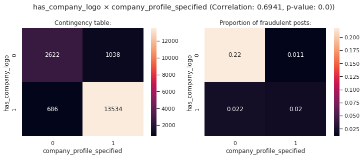

```python
show_feature1_x_feature2_info('has_company_logo', 'company_profile_specified')
```

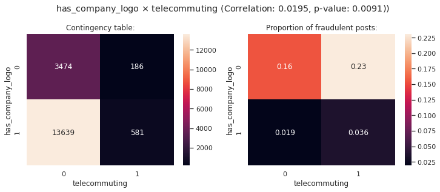

```python
show_feature1_x_feature2_info('has_company_logo', 'telecommuting')
```

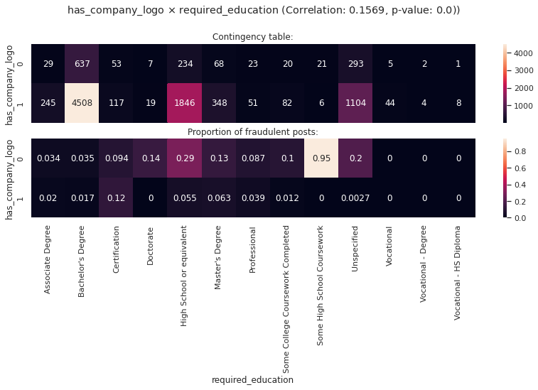

```python
show_feature1_x_feature2_info('has_company_logo', 'required_education', (14, 4.5), True)
```

## Associated words

We then use WordCloud to visualise frequent words associated with legitimate and fraud posts.

```python
df['text'] = df['title'].fillna('') + ' ' + df['location'].fillna('') + ' ' + df['company_profile'].fillna('')
df['text'] = df['text'] + ' ' + df['description'].fillna('') + ' ' + df['requirements'].fillna('') + ' ' + df['benefits'].fillna('')
df['text'] = df['text'].str.replace('\xa0', '').str.lower()

fraudjobs_text = df[df.fraudulent==1].text
actualjobs_text = df[df.fraudulent==0].text
```

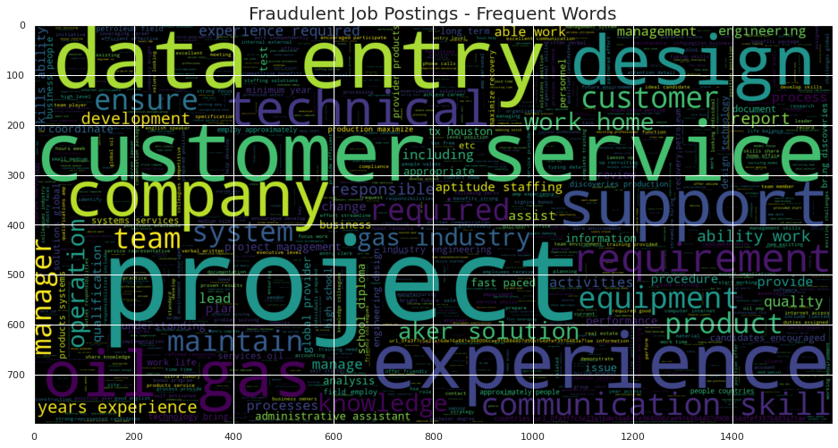

```python
STOPWORDS = spacy.lang.en.stop_words.STOP_WORDS
plt.figure(figsize = (16, 14))
wc = WordCloud(min_font_size = 3,  max_words = 3000 , width = 1600 , height = 800 , stopwords = STOPWORDS).generate(str(" ".join(fraudjobs_text)))
plt.imshow(wc, interpolation = 'bilinear');
plt.title('Fraudulent Job Postings - Frequent Words', size=20);
```

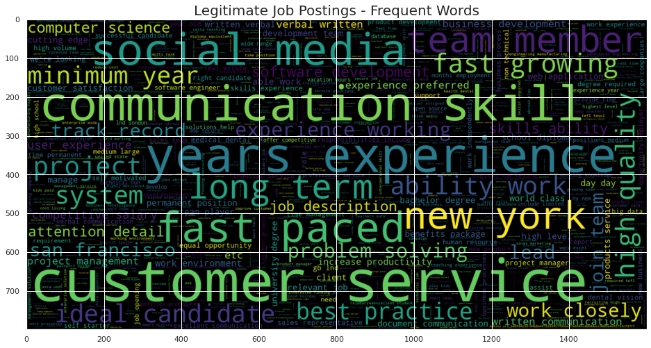

```python
STOPWORDS = spacy.lang.en.stop_words.STOP_WORDS
plt.figure(figsize = (16, 14))
wc = WordCloud(min_font_size = 3,  max_words = 3000 , width = 1600 , height = 800 , stopwords = STOPWORDS).generate(str(" ".join(actualjobs_text)))
plt.imshow(wc, interpolation = 'bilinear');
plt.title('Legitimate Job Postings - Frequent Words', size=20);
```

## Number of job postings from top 10 countries

A high number of job postings does not necessarily mean more fraudulent job postings. For accurate comparison, we will have to compare with the proportion of fraudulent posts based on job postings from individual country.

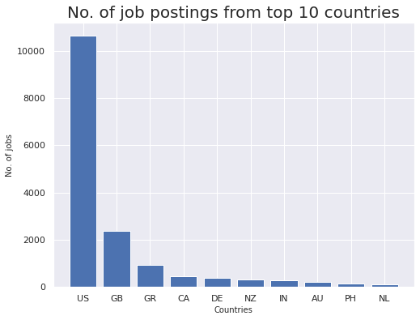

```python
country = dict(data_location.country.value_counts()[:10])

plt.figure(figsize=(8,6));
plt.title('No. of job postings from top 10 countries', size=20);
plt.bar(country.keys(), country.values());
plt.ylabel('No. of jobs', size=10);
plt.xlabel('Countries', size=10);
```

We will see whether these countries below show up again later when we extract countries from the top features used to identify fraudulent postings in our modelling step.

```python
country_meanfr_pt = pd.pivot_table(df, index='country', values='fraudulent', aggfunc=np.mean).sort_values(by='fraudulent', ascending=False)
country_meanfr_pt.columns = ['Proportion of fraudulent posts']
print('Top-10 country\'s values with the biggest proportions of fraudulent job postings:')
display(country_meanfr_pt.head(10))
```

```
Top-10 country's values with the biggest proportions of fraudulent job postings:
```

| country | Proportion of fraudulent posts |
| --- | --- |
| MY | 0.571429 |
| BH | 0.555556 |
| TW | 0.500000 |
| QA | 0.285714 |
| AU | 0.186916 |
| ID | 0.076923 |
| US | 0.068506 |
| SA | 0.066667 |
| PL | 0.039474 |
| PK | 0.037037 |

# Metrics

Classfication accuracy is not a good measurement as our dummy classifier attains a 95.6% accuracy due to the class imbalance. Hence, other metrics are used like AUC-ROC score, Matthews Correlation Coefficient (MCC) and F1 Scores are used.

From [this](https://towardsdatascience.com/matthews-correlation-coefficient-when-to-use-it-and-when-to-avoid-it-310b3c923f7e) article, F1 is better than MCC for our case. In actuality, we use [F2 score](https://scikit-learn.org/stable/modules/generated/sklearn.metrics.fbeta_score.html) to focus more on minimising false negatives, as it is more sensitive to recall due to us wanting our model to identify more fake postings.

$F_2 = \frac{(1 + 2^2) \text{ } \cdot \text{ Precision } \cdot \text{ Recall}}{2^2 \text{ } \cdot \text{ Precision } + \text{ Recall}}$ Click [here](https://machinelearningmastery.com/fbeta-measure-for-machine-learning/) for source.

Although we might get more false positives, it is okay we want to identify the maximum number of real fake postings, because the fake postings does more harm then missing out on the real postings.

Hence, for this dataset, we will be monitoring the *ROC AUC Score* and *F2 Score*.

```
Classification Acc.	: 0.9559284116331096
Matthew's Corr. Coeff.	: 0.0
ROC AUC Score		: 0.5
F1 Score		: 0.0
F2 Score		: 0.0

Confusion Matrix:
```

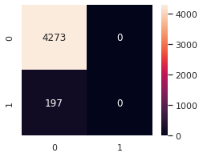

```python
X_train, X_test, y_train, y_test = train_test_split(df['description'].fillna('nil'), df['fraudulent'], random_state=0)

vect = TfidfVectorizer(min_df=1, max_features=1000).fit(X_train)
X_train_vectorized = vect.transform(X_train)
X_test_vectorized = vect.transform(X_test)
dummy_clf = DummyClassifier(strategy="most_frequent")
dummy_clf.fit(X_train_vectorized, y_train)
predictions = dummy_clf.predict(X_test_vectorized)

# Print some metric scores
print('Classification Acc.\t:', dummy_clf.score(X_test_vectorized, y_test))
print('Matthew\'s Corr. Coeff.\t:', matthews_corrcoef(y_test, predictions))
print('ROC AUC Score\t\t:', roc_auc_score(y_test, predictions))
print('F1 Score\t\t:', f1_score(y_test, predictions))
print('F2 Score\t\t:', fbeta_score(y_test, predictions, 2))
print('\nConfusion Matrix:')
plt.subplots(1, 1, figsize=(4, 3))
sb.heatmap(confusion_matrix(y_test, predictions), annot=True, square=True, fmt='d');
```

# Pre-processing

We first define some functions so that we can call them later.

- `custom_metrics` function to test dataset scores during pre-processing stage
- `show_samples` function to show what each preprocessing step does

```python
def custom_metrics(X, Y=df['fraudulent']):

    X_train, X_test, y_train, y_test = train_test_split(X, Y, random_state=0)
    vect = TfidfVectorizer(min_df=1, max_features=2000).fit(X_train)
    X_train_vectorized = vect.transform(X_train)
    X_test_vectorized = vect.transform(X_test)
    model = LogisticRegression(C=28, solver='liblinear')
    model.fit(X_train_vectorized, y_train)
    predictions = model.predict(X_test_vectorized)

    # Print some metric scores
    print('Classification Accuracy\t:', model.score(X_test_vectorized, y_test))
    print('Matthew\'s Corr. Coeff.\t:', matthews_corrcoef(y_test, predictions))
    print('ROC AUC Score\t\t:', roc_auc_score(y_test, predictions))
    print('F1 Score\t\t:', f1_score(y_test, predictions))
    print('F2 Score\t\t:', fbeta_score(y_test, predictions, 2))
    print('\nConfusion Matrix:')
    plt.subplots(1, 1, figsize=(4, 3))
    sb.heatmap(confusion_matrix(y_test, predictions), annot=True, square=True, fmt='d');


def show_samples(mode='Before'):
    df_used = df
    if mode == 'After': df_used = df_cleaned
    print(f'--- {mode} Pre-processing (Some Samples) ---', end='\n\n')
    print(df_used['description'].iloc[0], end='\n\n')
    print(df_used['description'].iloc[520], end='\n\n')
    print(df_used['company_profile'].iloc[381], end='\n\n')
    print(df_used['benefits'].iloc[6057], end='\n\n')
```

### Baseline

The samples and scores below are our baseline before any pre-processing methods are applied.

```python
show_samples('Before')
```

```
--- Before Pre-processing (Some Samples) ---

Food52, a fast-growing, James Beard Award-winning online food community and crowd-sourced and curated recipe hub, is currently interviewing full- and part-time unpaid interns to work in a small team of editors, executives, and developers in its New York City headquarters.Reproducing and/or repackagi…

Are you a degree-qualified marketing or technology professional? Do you want to work as a product owner within our Agile software development teams? Do you want to apply your skills to bring to market the world’s most advanced SaaS-based transportation compliance, health and safety and performance m…

Company Website: #URL_b0bc289d014ce1647b7dbe8ffe0e121d1f3ded55cbf9e3c20987b3cf1f8d3b5d#Advisor Websites has been a player in the financial services industry since 2002, building crisp, professional, and compliant websites exclusively for members of the financial services industry all across North Am…

This position is high paying and you will be paid WEEKLY via direct deposit, check, or company provided debit card. Candidate will be paid $50-$70 Per hour commensurate with experience and education.  APPLY NOW AT #EMAIL_c9b5d8a60f3d80be13dd02ffe5d212c047b92ba679c296dfae7c102952fbb534# AND GET START…
```

```
Classification Accuracy	: 0.9720357941834452
Matthew's Corr. Coeff.	: 0.6483526484870618
ROC AUC Score		: 0.8037939796692963
F1 Score		: 0.6612466124661247
F2 Score		: 0.6354166666666666

Confusion Matrix:
```

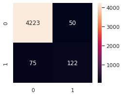

```python
custom_metrics(df['description'].fillna('nil'), df['fraudulent'])
```

### Feature extraction

After testing, we found that including all variables as specified or not specified decreased the scores of the various metrics. So, we only include it for `company_profile_specified`.

```python
df_cleaned = pd.DataFrame()

df_cleaned['telecommuting'] = df['telecommuting'].replace({1: 'telecommuting_yes', 0: 'telecommuting_no'})
df_cleaned['country'] = ('country_' + data_location['country'].fillna('none')).str.lower()
df_cleaned['state'] = ('state_' + data_location['state'].fillna('none')).str.lower()
df_cleaned['city'] = ('city_' + data_location['city'].fillna('none')).str.lower()
df_cleaned['company_logo'] = df['has_company_logo'].replace({1: 'company_logo_yes', 0: 'company_logo_no'})
df_cleaned['company_profile_specified'] = df['company_profile_specified'].replace({1: 'company_profile_yes', 0: 'company_profile_no'})
df_cleaned['questions'] = df['has_questions'].replace({1: 'has_questions_yes', 0: 'has_questions_no'})
df_cleaned['employment_type'] = ('employment_type_' + df['employment_type'].str.replace(r' ', '').str.lower()).fillna('')
df_cleaned['required_experience'] = ('required_experience_' + df['required_experience'].str.replace(r' ', '_').str.lower()).fillna('')
df_cleaned['required_education'] = ('required_education_' + df['required_education'].str.replace(r' ', '_').str.lower()).fillna('')
df_cleaned['industry'] = ('industry_' + df['industry'].str.replace(r' ', '_').str.lower()).fillna('')
df_cleaned['function'] = ('function_' + df['function'].str.replace(r' ', '_').str.lower()).fillna('')
df_cleaned['title'] = df['title'].str.replace(r'-', '').str.lower().fillna('')
df_cleaned['department'] = ('department_' + df['department'].str.replace(r' ', '_').str.lower()).fillna('')

df_cleaned

# -----------------------------------------------

# df_cleaned = pd.DataFrame()

# df_cleaned['telecommuting'] = df['telecommuting'].replace({1: 'telecommuting_yes', 0: 'telecommuting_no'})
# df_cleaned['country'] = ('country_' + df['location'].str[:2] + ' country_specified').fillna('country_NOT_specified')
# df_cleaned['company_logo'] = df['has_company_logo'].replace({1: 'company_logo_yes', 0: 'company_logo_no'})
# df_cleaned['questions'] = df['has_questions'].replace({1: 'has_questions_yes', 0: 'has_questions_no'})
# df_cleaned['employment_type'] = ('employment_type_' + df['employment_type'].str.replace(r' ', '').str.lower() + ' employment_specified').fillna('employment_NOT_specified')
# df_cleaned['required_experience'] = ('required_experience_' + df['required_experience'].str.replace(r' ', '_').str.lower() + ' experience_specified').fillna('experience_NOT_specified')
# df_cleaned['required_education'] = ('required_education_' + df['required_education'].str.replace(r' ', '_').str.lower() + ' education_specified').fillna('education_NOT_specified')
# df_cleaned['industry'] = ('industry_' + df['industry'].str.replace(r' ', '_').str.lower() + ' industry_specified').fillna('industry_NOT_specified')
# df_cleaned['function'] = ('function_' + df['function'].str.replace(r' ', '_').str.lower() + ' function_specified').fillna('function_NOT_specified')
# df_cleaned['title'] = (df['title'].str.replace(r'-', '').str.lower() + ' title_specified').fillna('title_NOT_specified')
# df_cleaned['department'] = ('department_' + df['department'].str.replace(r' ', '_').str.lower() + ' department_specified').fillna('department_NOT_specified')

# df_cleaned
```

|  | telecommuting | country | state | city | company_logo | company_profile_specified | questions | employment_type | required_experience | required_education | industry | function | title | department |
| --- | --- | --- | --- | --- | --- | --- | --- | --- | --- | --- | --- | --- | --- | --- |
| 0 | telecommuting_no | country_us | state_ny | city_new york | company_logo_yes | company_profile_yes | has_questions_no | employment_type_other | required_experience_internship |  |  | function_marketing | marketing intern | department_marketing |
| 1 | telecommuting_no | country_nz | state_unspecified | city_auckland | company_logo_yes | company_profile_yes | has_questions_no | employment_type_full-time | required_experience_not_applicable |  | industry_marketing_and_advertising | function_customer_service | customer service cloud video production | department_success |
| 2 | telecommuting_no | country_us | state_ia | city_wever | company_logo_yes | company_profile_yes | has_questions_no |  |  |  |  |  | commissioning machinery assistant (cma) |  |
| 3 | telecommuting_no | country_us | state_dc | city_washington | company_logo_yes | company_profile_yes | has_questions_no | employment_type_full-time | required_experience_mid-senior_level | required_education_bachelor's_degree | industry_computer_software | function_sales | account executive washington dc | department_sales |
| 4 | telecommuting_no | country_us | state_fl | city_fort worth | company_logo_yes | company_profile_yes | has_questions_yes | employment_type_full-time | required_experience_mid-senior_level | required_education_bachelor's_degree | industry_hospital_&_health_care | function_health_care_provider | bill review manager |  |
| ... | ... | ... | ... | ... | ... | ... | ... | ... | ... | ... | ... | ... | ... | ... |
| 17875 | telecommuting_no | country_ca | state_on | city_toronto | company_logo_yes | company_profile_yes | has_questions_yes | employment_type_full-time | required_experience_mid-senior_level |  | industry_computer_software | function_sales | account director distribution | department_sales |
| 17876 | telecommuting_no | country_us | state_pa | city_philadelphia | company_logo_yes | company_profile_yes | has_questions_yes | employment_type_full-time | required_experience_mid-senior_level | required_education_bachelor's_degree | industry_internet | function_accounting/auditing | payroll accountant | department_accounting |
| 17877 | telecommuting_no | country_us | state_tx | city_houston | company_logo_no | company_profile_yes | has_questions_no | employment_type_full-time |  |  |  |  | project cost control staff engineer cost cont... |  |
| 17878 | telecommuting_no | country_ng | state_la | city_lagos | company_logo_no | company_profile_no | has_questions_yes | employment_type_contract | required_experience_not_applicable | required_education_professional | industry_graphic_design | function_design | graphic designer |  |
| 17879 | telecommuting_no | country_nz | state_n | city_wellington | company_logo_yes | company_profile_yes | has_questions_yes | employment_type_full-time | required_experience_mid-senior_level |  | industry_computer_software | function_engineering | web application developers | department_engineering |

17880 rows × 14 columns

### Text cleaning

The codeblock below uses regular expression (RegEx) to clean the text fields `company_profile`, `description`, `requirements` and `benefits`:

- remove special characters, email and URL
- aA or a.A --> a A
- remove punctuations, digits and double spaces
- convert all text to lowercase

```python
text_fields = ['company_profile', 'description', 'requirements', 'benefits']

for item in text_fields:
    df_cleaned[item] = (df[item].str.replace(r'\\n', ' ').str.replace(r'&amp', ' ').str.replace(r'\xa0', ' ')
                                .str.replace(r'\$str=',' ').str.replace(r'AppKey=*[0-9a-z]+', ' ')
                                .str.replace(r'#EMAIL_[\w]+#', ' ').str.replace(r'#URL_[\w]+#', ' ').str.replace(r'#PHONE_[\w]+#', ' ')
                                .str.replace(r'http[s]?://(?:[a-zA-Z]|[0-9]|[$-_@.&+]|[!*\(\),]|(?:%[0-9a-fA-F][0-9a-fA-F]))+', ' ')
                                # Replace aA / .A to "a A" / ". A"
                                .str.replace(r'(?<=[a-z])(?=[A-Z])', ' ').str.replace(r'(?<=[.,?!:])(?=[A-Z])', ' ')
                                # Remove punctuation, digits, double spaces and convert all to lowercase
                                .str.replace(r'[\+\*=@#<>\(\)\[\]\^_/"-]+', '  ')
                                .str.replace(r'[^\w\s]*', '').str.replace(r'[0-9]+', ' ')
                                .str.replace(r'[\s]+', ' ').str.lower())

df_cleaned[text_fields] = df_cleaned[text_fields].fillna('')
df_cleaned['fraud'] = df['fraudulent']

show_samples('After')
```

```
--- After Pre-processing (Some Samples) ---

food a fast growing james beard award winning online food community and crowd sourced and curated recipe hub is currently interviewing full and part time unpaid interns to work in a small team of editors executives and developers in its new york city headquarters reproducing and or repackaging exist…

are you a degree qualified marketing or technology professional do you want to work as a product owner within our agile software development teams do you want to apply your skills to bring to market the worlds most advanced saa s based transportation compliance health and safety and performance mana…

company website advisor websites has been a player in the financial services industry since building crisp professional and compliant websites exclusively for members of the financial services industry all across north america through a saas business model our head office is located on the beautiful…

this position is high paying and you will be paid weekly via direct deposit check or company provided debit card candidate will be paid per hour commensurate with experience and education apply now at and get started today
```

### Remove stopwords

Stopwords are common words like "I, the, an" which needs to be removed as they will be counted in during the vocabulary frequency.

```python
from nltk.corpus import stopwords

stop_words = list(get_stop_words('en'))         # About 900 stopwords
nltk_words = list(stopwords.words('english'))   # About 150 stopwords
stop_words.extend(nltk_words)
stop = set(stop_words)

def remove_stopwords(sentence):
    tokens = sentence.split()
    tokens = [token for token in tokens if token not in stop]
    return " ".join(tokens)

for col in text_fields:
    df_cleaned[col] = df_cleaned[col].map(remove_stopwords)

show_samples('After')
```

```
--- After Pre-processing (Some Samples) ---

food fast growing james beard award winning online food community crowd sourced curated recipe hub currently interviewing full part time unpaid interns work small team editors executives developers new york city headquarters reproducing repackaging existing food content number partner sites huffingt…

degree qualified marketing technology professional want work product owner within agile software development teams want apply skills bring market worlds advanced saa based transportation compliance health safety performance management products looking product managers lead implementation product roa…

company website advisor websites player financial services industry since building crisp professional compliant websites exclusively members financial services industry across north america saas business model head office located beautiful west coast canada vancouver british columbia offer amazing c…

position high paying paid weekly via direct deposit check company provided debit card candidate paid per hour commensurate experience education apply get started today
```

### Combining the text features

```
Sample (All features):

telecommuting_no country_us state_ny city_new york company_logo_yes company_profile_yes has_questions_no employment_type_other required_experience_internship function_marketing marketing intern department_marketing food weve created groundbreaking award winning cooking site support connect celebrate…

Classification Accuracy	: 0.9845637583892617
Matthew's Corr. Coeff.	: 0.8051277823670699
ROC AUC Score		: 0.8708731843555508
F1 Score		: 0.8099173553719009
F2 Score		: 0.770440251572327

Confusion Matrix:
```

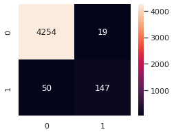

```python
# Add all the features here
df_end = pd.DataFrame()

df_end['text'] = df_cleaned.iloc[:, 0]
for col in df_cleaned.columns[1:-1]:
    df_end['text'] = df_end['text'] + ' ' + df_cleaned[col]

# Replace multiple spaces with a single space
df_end['text'] = df_end['text'].str.replace(r'[\s]+', ' ')
df_end['fraud'] = df_cleaned['fraud']

print('Sample (All features):\n')
print(df_end['text'][0], end='\n\n')
custom_metrics(df_end.text, df_end.fraud)
```

### Lemmatization

Lemmatization is the act of changing back a word to its base form since the other forms of the word has the same meaning and will only increase the vocabulary count.  
*Image source: https://medium.com/swlh/introduction-to-stemming-vs-lemmatization-nlp-8c69eb43ecfe*

[figure not shown]

For our case, we found that by using Lemmatization on `company_profile`, `description`, `requirements` and `benefits`, the scores for all metrics decreased. So, we won't be using it for our models later.

Note: The code below takes **10 minutes** to run, so we have provided the lemmatized dataset that we have previously gotten.

```
Sample (All features + Lemmatized text fields):

telecommuting_no country_us state_ny city_new york company_logo_yes company_profile_yes has_questions_no employment_type_other required_experience_internship function_marketing marketing intern department_marketing food weve create groundbreaking award win cooking site support connect celebrate home…

Classification Accuracy	: 0.983668903803132
Matthew's Corr. Coeff.	: 0.7949647257871792
ROC AUC Score		: 0.8704051291250336
F1 Score		: 0.8010899182561309
F2 Score		: 0.7672233820459292

Confusion Matrix:
```

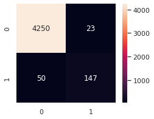

```python
# # Lemmatization codeblock #

# def get_simple_pos(tag):
#     if tag.startswith('J'):
#         return wordnet.ADJ
#     elif tag.startswith('V'):
#         return wordnet.VERB
#     elif tag.startswith('N'):
#         return wordnet.NOUN
#     elif tag.startswith('R'):
#         return wordnet.ADV
#     else:
#         return wordnet.NOUN

# lemmatizer = WordNetLemmatizer()
# def lemmatize_words(text):
#     final_text = []
#     for i in text.split():
#         if i.strip().lower() not in stop:
#             pos = pos_tag([i.strip()])
#             word = lemmatizer.lemmatize(i.strip(), get_simple_pos(pos[0][1]))
#             final_text.append(word.lower())
#     return " ".join(final_text)

# for col in text_fields:
#     df_cleaned[col] = df_cleaned[col].map(lemmatize_words)

# # Add all the features here
# df_lemmatized = pd.DataFrame()

# df_lemmatized['text'] = df_cleaned.iloc[:, 0]
# for col in df_cleaned.columns[1:-1]:
#     df_lemmatized['text'] = df_lemmatized['text'] + ' ' + df_cleaned[col]

# # Replace multiple spaces with a single space
# df_lemmatized['text'] = df_lemmatized['text'].str.replace(r'[\s]+', ' ')
# df_lemmatized['fraud'] = df_cleaned['fraud']

# print('Sample (All features):\n')
# print(df_lemmatized['text'][0], end='\n\n')
# custom_metrics(df_lemmatized.text, df_lemmatized.fraud)

# df_lemmatized.to_csv('fake_job_postings_lemmatized.csv')

## ----------------------------------------------------------------------------

df_lemmatized = pd.read_csv('fake_job_postings_lemmatized.csv')

# Replace multiple spaces with a single space
df_lemmatized['text'] = df_lemmatized['text'].str.replace(r'[\s]+', ' ')

print('Sample (All features + Lemmatized text fields):\n')
print(df_lemmatized['text'][0], end='\n\n')
custom_metrics(df_lemmatized['text'], df_lemmatized['fraud'])
del df_lemmatized
```

# Oversampling

- As the proportion of fraudulent postings is very small, we have to oversample it so that the models are able to determine the features better.
- Oversampling, however, for the test set should not be done as the test set should reflect the real ratio of fraudulent job postings in real life, which is not common.

We now test out which oversampling strategy is the best so that we can use it later.

*Source: https://machinelearningmastery.com/smote-oversampling-for-imbalanced-classification/*

```python
def oversample_test(sampler, X, Y=df['fraudulent']):

    X_train, X_test, y_train, y_test = train_test_split(X, Y, random_state=0)
    vect = TfidfVectorizer(min_df=1, max_features=2000).fit(X_train)
    X_train_vectorized = vect.transform(X_train)
    X_test_vectorized = vect.transform(X_test)
    oversample = sampler(sampling_strategy=0.8, random_state=0)
    X_train_vectorized, y_train = oversample.fit_resample(X_train_vectorized, y_train)
    model = LogisticRegression(C=28, solver='liblinear')
    model.fit(X_train_vectorized, y_train)
    predictions = model.predict(X_test_vectorized)

    # Print some metric scores
    print('Classification Accuracy\t:', model.score(X_test_vectorized, y_test))
    print('Matthew\'s Corr. Coeff.\t:', matthews_corrcoef(y_test, predictions))
    print('ROC AUC Score\t\t:', roc_auc_score(y_test, predictions))
    print('F1 Score\t\t:', f1_score(y_test, predictions))
    print('F2 Score\t\t:', fbeta_score(y_test, predictions, 2))
    print('\nConfusion Matrix:')
    plt.subplots(1, 1, figsize=(4, 3))
    sb.heatmap(confusion_matrix(y_test, predictions), annot=True, square=True, fmt='d');
```

```
Classification Accuracy	: 0.9796420581655481
Matthew's Corr. Coeff.	: 0.7749685045058415
ROC AUC Score		: 0.9118779112381961
F1 Score		: 0.7838479809976248
F2 Score		: 0.8152173913043478

Confusion Matrix:
```

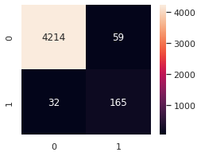

```python
# SMOTE oversampling strategy
oversample_test(SMOTE, df_end.text, df_end.fraud)
```

```
Classification Accuracy	: 0.9796420581655481
Matthew's Corr. Coeff.	: 0.7762497976552465
ROC AUC Score		: 0.9142989684965567
F1 Score		: 0.784869976359338
F2 Score		: 0.8185404339250493

Confusion Matrix:
```

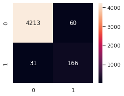

```python
# SVMSMOTE oversampling strategy
oversample_test(SVMSMOTE, df_end.text, df_end.fraud)
```

```
Classification Accuracy	: 0.9803131991051454
Matthew's Corr. Coeff.	: 0.7757147809290322
ROC AUC Score		: 0.9025447236276418
F1 Score		: 0.7853658536585366
F2 Score		: 0.8041958041958043

Confusion Matrix:
```

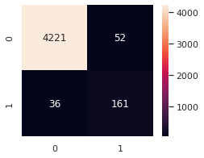

```python
# BorderlineSMOTE oversampling strategy
oversample_test(BorderlineSMOTE, df_end.text, df_end.fraud)
```

```
Classification Accuracy	: 0.9774049217002237
Matthew's Corr. Coeff.	: 0.7569663488240599
ROC AUC Score		: 0.9107077731619031
F1 Score		: 0.7656612529002319
F2 Score		: 0.8072407045009784

Confusion Matrix:
```

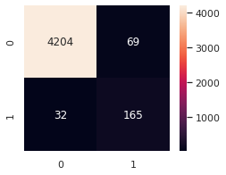

```python
# ADASYN oversampling strategy
oversample_test(ADASYN, df_end.text, df_end.fraud)
```

We find that the SVMSMOTE oversampling strategy provides the best score metrics, but it takes very long, so we will be using SMOTE throughout our models.

- On top of that, an increase in F2 Score from *0.770 to 0.815* can be seen from due to oversampling.
- This shows that oversampling is important for our imbalanced dataset.

# Modelling

- Random Forest Classifier
- Logistic Regression
- Bernoulli Naive Bayes
- Multinomial Naive Bayes
- State Vector Machine (SVM)
- Simple Neural Network

## Some custom functions

- The functions below are used to help us in Hyperparameter Tuning and reducing code clutter.
- Two dictionaries below are used to record the ROC AUC Score and F2 Score of each classifier.

```python
roc_dict = {}
f2_dict = {}

# Use final model and print all metric scores
def skmodel(model):
    model.fit(X_train_vectorized, y_train)
    predictions = model.predict(X_test_vectorized)
    # Print some metric scores
    print('Classification Accuracy\t:', model.score(X_test_vectorized, y_test))
    print('Matthew\'s Corr. Coeff.\t:', matthews_corrcoef(y_test, predictions))
    print('ROC AUC Score\t\t:', roc_auc_score(y_test, predictions))
    print('F1 Score\t\t:', f1_score(y_test, predictions))
    print('F2 Score\t\t:', fbeta_score(y_test, predictions, 2))
    print('\nConfusion Matrix:')
    plt.subplots(1, 1, figsize=(4, 3))
    sb.heatmap(confusion_matrix(y_test, predictions), annot=True, square=True, fmt='d');
    return model, roc_auc_score(y_test, predictions), fbeta_score(y_test, predictions, 2)

# Loop through the model with different parameters, then return both F1 and F2 scores
def skmodel_loop(model):
    model.fit(X_train_vectorized, y_train)
    predictions = model.predict(X_test_vectorized)
    return f1_score(y_test, predictions), fbeta_score(y_test, predictions, 2)

# Print the results of hyperparameter tuning
def print_metrics(metrics, xlabel):
    f1 = [metric[0] for metric in metrics]
    f2 = [metric[1] for metric in metrics]
    # Semilog or normal plot
    if param[-1]/param[0] > 100:
        plt.semilogx(param, f1);
        plt.semilogx(param, f2);
    else:
        plt.plot(param, f1);
        plt.plot(param, f2);
    plt.xlabel(xlabel);
    plt.ylabel('Metrics');
    plt.legend(['F1 Score', 'F2 Score']);
    plt.title(f'Highest F2 Score at {xlabel} = {param[f2.index(max(f2))]}')
```

## Vectorizing once only for ease

- We only use 20000 text features as increasing it further decreases our score metrics and adds to the processing time.
- Apart from unigram, bigrams are also used as they might be a good feature.
- Oversampling techniques are also applied here to correct the imbalanced dataset.

```
Vectorising your data ...
• Number of features: 20000
• Vector transformation done!
```

```
Percentage of fraudulent job postings for train set = 44.44 %
(22933, 20000) (22933,)
```

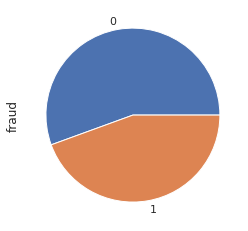

```python
print('Vectorising your data ...  ')
X_train, X_test, y_train, y_test = train_test_split(df_end.text, df_end.fraud, random_state=0)

# oversampler_multiplier = 16
# # Sampling is done after train-test-split to avoid data leak
# X_train = X_train.append(np.repeat(X_train.iloc[np.where(y_train == 1)], oversampler_multiplier-1)).sample(frac=1, random_state=0)
# y_train = y_train.append(np.repeat(y_train.iloc[np.where(y_train == 1)], oversampler_multiplier-1)).sample(frac=1, random_state=0)
# X_test = X_test.append(np.repeat(X_test.iloc[np.where(y_test == 1)], oversampler_multiplier-1)).sample(frac=1, random_state=0)
# y_test = y_test.append(np.repeat(y_test.iloc[np.where(y_test == 1)], oversampler_multiplier-1)).sample(frac=1, random_state=0)

vect = TfidfVectorizer(min_df=1, ngram_range=(1, 2), max_features=20000).fit(X_train)
print(f'• Number of features: {len(vect.get_feature_names())}')
X_train_vectorized = vect.transform(X_train)
X_test_vectorized = vect.transform(X_test)
print('• Vector transformation done!')

# Oversampling technique
# undersample = RandomUnderSampler(sampling_strategy=0.5)
# steps = [('o', oversample), ('u', undersample)]
# pipeline = Pipeline(steps=steps)
oversample = SMOTE(sampling_strategy=0.8, random_state=0)
X_train_vectorized, y_train = oversample.fit_resample(X_train_vectorized, y_train)

# Calculate percentage of fraudulent job postings
temp = pd.Series(y_train, name='fraud').value_counts()
print(f'\nPercentage of fraudulent job postings for train set = {round(temp[1]/len(y_train)*100, 2)} %')
temp.plot(kind="pie");
del temp

print(X_train_vectorized.shape, y_train.shape)
```

## Random forest classifier

- `GridSearchCV` is a library function in sklearn's `model_selection` package. It tries all the combinations of the values passed in the dictionary and evaluates the model for each combination using the `Cross-Validation` (`CV` in `GridSearchCV` stands for cross validation) method in order to determine the hyperparameter value set which provides the best ROC AUC score (`scoring = 'roc_auc'`). 5-fold cross validation is applied in this case.
- `rf_tune` is the RandomForestClassifier object used to find best parameter.

Reference:

1. [Hyperparameter Tuning with GridSearchCV](https://www.mygreatlearning.com/blog/gridsearchcv/)
2. [What is Cross Validation in Machine learning? Types of Cross Validation](https://www.mygreatlearning.com/blog/cross-validation/#sh212)

```python
# # NOTE: The code below takes 70 minutes to run (pre-run output is shown below)

# # Create RandomForestClassifier object
# rf_tune = RandomForestClassifier(random_state=0, class_weight="balanced")

# # Hyperparameter tuning
# param_grid = {
#     'n_estimators': [100, 200, 500],
#     'max_features': ['auto', 'sqrt','log2'],
# }
# grid_rf = GridSearchCV(rf_tune, param_grid, cv = 5, scoring = 'roc_auc', n_jobs = -1, verbose = 1);

# # Random Forest Classification using Train Data
# grid_rf.fit(X_train_vectorized, y_train)
```

Pre-run output of this cell:

[figure not shown]

**Performance**

- Beside `oversampling` method, `class weighting` is also applied in this case to improve RF classifier's performance as the RF classifier tends to bias towards the majority class. Class weighting imposts a cost penalty to the minority class misclassification by assignining high weight to the minority class.
- Param `class_weight="balanced"` will replicate the smaller class until has as many sample as in the larger one but in an implicit way.
- In the following code, we can see the `ROC AUC Score` and `F2 Score` slightly increase/decrease (depending on each run) after class weighting. One possible reason is the data is approximately balanced after oversampling (44.44% fraudulent data), thus class weighting doesn't help a lot in this case.

*Reference: [Using Random Forest to Learn Imbalanced Data](https://statistics.berkeley.edu/sites/default/files/tech-reports/666.pdf)*

```python
# # Performance of most suit hyperparameter
# print("Best score\t\t:", grid_rf.best_score_)
# print("Best parameter found\t:",grid_rf.best_params_)
```

Pre-run output of this cell:

Before class weighting:

```
Classification Accuracy	: 0.9823266219239374
Matthew's Corr. Coeff.	: 0.766842213431975
ROC AUC Score		: 0.8091766148202442
F1 Score		: 0.7554179566563467
F2 Score		: 0.6673960612691465

Confusion Matrix:
```

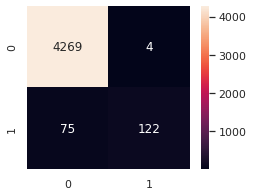

```python
clf = 'Random Forest Classifier'
trained_model0, roc_dict[clf], f2_dict[clf] = skmodel(RandomForestClassifier(random_state=0, n_estimators=500, max_features='log2'))
```

After class weighting (score metrics increases/decreases *slightly*): [increases in this run]

```
Classification Accuracy	: 0.9827740492170023
Matthew's Corr. Coeff.	: 0.7736155082825039
ROC AUC Score		: 0.8166738142105846
F1 Score		: 0.764525993883792
F2 Score		: 0.6808278867102396

Confusion Matrix:
```

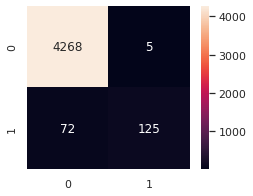

```python
clf = 'Random Forest Classifier'
trained_model0, roc_dict[clf], f2_dict[clf] = skmodel(RandomForestClassifier(random_state=0, class_weight='balanced', n_estimators=500, max_features='log2'))
```

## Logistic regression classifier

**See conclusion for how the model works ^**

*Note: Class weighting is not applied for subsequent models as it decreases the metric scores*

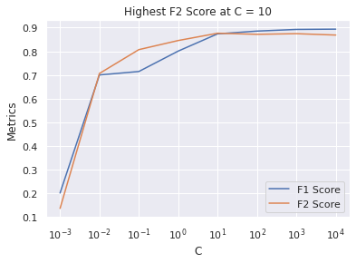

```python
# Hyperparameter tuning
param = [0.001, 0.01, 0.1, 1, 10, 100, 1000, 10000]
metrics = [skmodel_loop(LogisticRegression(C=i, solver='liblinear')) for i in param]
print_metrics(metrics, 'C')
```

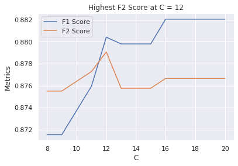

```python
# Hyperparameter tuning
param = np.arange(8, 21, 1)
metrics = [skmodel_loop(LogisticRegression(C=i, solver='liblinear')) for i in param]
print_metrics(metrics, 'C')
```

```
Classification Accuracy	: 0.9894854586129754
Matthew's Corr. Coeff.	: 0.8749112552490224
ROC AUC Score		: 0.9363949768407698
F1 Score		: 0.8804071246819337
F2 Score		: 0.8790650406504066

Confusion Matrix:
```

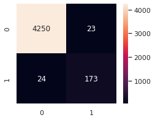

```python
clf = 'Logistic Regression'
trained_model1, roc_dict[clf], f2_dict[clf] = skmodel(LogisticRegression(C=12, solver='liblinear'))
```

The graphic below shows which features are important when classifying the job postings. This confirms the hypothesis made earlier that no `company_logo` and no `company_profile` will be a good predictor for fraud job postings.

However, this will not be used to determine the associated sentiment with each feature as only **20000 out of 837531 features** are used. This will be discussed at the end.

```python
eli5.explain_weights(trained_model1, feature_names=vect.get_feature_names(), top=(20, 20))
```

**y=1** top features

| Weight<sup>?</sup> | Feature |
| --- | --- |
| +9.431 | accion |
| +9.226 | company_logo_no company_profile_no |
| +9.206 | apply using |
| +7.663 | city_unspecified company_logo_no |
| +7.271 | company_logo_no |
| +7.230 | link |
| +6.770 | novation |
| +6.767 | subsea |
| +6.646 | money |
| +6.505 | industry_accounting |
| +6.460 | company_profile_no |
| +5.978 | data entry |
| +5.931 | time industry_hospital_ |
| +5.899 | company_profile_no has_questions_no |
| +5.753 | aptitude staffing |
| +5.252 | engineering |
| +5.215 | bottom line |
| +5.010 | entry |
| +4.973 | supplier |
| +4.946 | bright |
| *… 5428 more positive …* |  |
| *… 14533 more negative …* |  |
| -3.078 | commission |
| -3.097 | agency |
| -3.147 | handling |
| -3.165 | website |
| -3.181 | based |
| -3.206 | monday |
| -3.207 | custom |
| -3.225 | company_logo_yes company_profile_no |
| -3.375 | days |
| -3.430 | essential |
| -3.469 | exceptional |
| -3.496 | digital |
| -3.520 | company_logo_yes |
| -3.611 | time required_experience_associate |
| -3.698 | allied |
| -4.181 | client |
| -4.256 | growing |
| -4.327 | english |
| -4.596 | <BIAS> |
| -4.703 | companies |

## Bernoulli naive bayes classifier

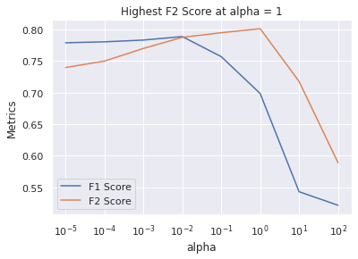

```python
# Hyperparameter tuning
param = [0.00001, 0.0001, 0.001, 0.01, 0.1, 1, 10, 100]
metrics = [skmodel_loop(BernoulliNB(alpha=i)) for i in param]
print_metrics(metrics, 'alpha')
```

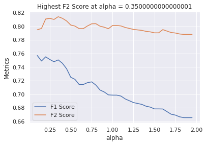

```python
# Hyperparameter tuning
param = np.arange(0.1, 2, 0.05)
metrics = [skmodel_loop(BernoulliNB(alpha=i)) for i in param]
print_metrics(metrics, 'alpha')
```

```
Classification Accuracy	: 0.9747203579418344
Matthew's Corr. Coeff.	: 0.7445022317356648
ROC AUC Score		: 0.9214088937621543
F1 Score		: 0.7505518763796909
F2 Score		: 0.814176245210728

Confusion Matrix:
```

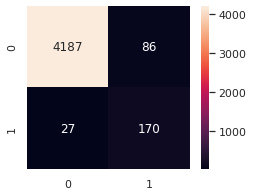

```python
clf = 'BernoulliNB'
trained_model2, roc_dict[clf], f2_dict[clf] = skmodel(BernoulliNB(alpha=0.35))
```

```python
# Weights visualisation not supported
eli5.explain_weights(trained_model2, feature_names=vect.get_feature_names(), top=(20, 20))
```

Error: estimator BernoulliNB(alpha=0.35, binarize=0.0, class_prior=None, fit_prior=True) is not supported

## Multinomial naive bayes classifier

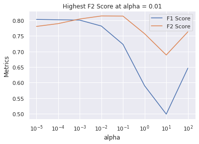

```python
# Hyperparameter tuning
param = [0.00001, 0.0001, 0.001, 0.01, 0.1, 1, 10, 100]
metrics = [skmodel_loop(MultinomialNB(alpha=i)) for i in param]
print_metrics(metrics, 'alpha')
```

```
Classification Accuracy	: 0.9794183445190157
Matthew's Corr. Coeff.	: 0.7731158029369221
ROC AUC Score		: 0.9117608974305668
F1 Score		: 0.7819905213270142
F2 Score		: 0.8144126357354392

Confusion Matrix:
```

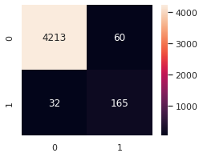

```python
clf = 'MultinomialNB'
trained_model3, roc_dict[clf], f2_dict[clf] = skmodel(MultinomialNB(alpha=0.01))
```

```python
# Weights visualisation not supported
eli5.explain_weights(trained_model3, feature_names=vect.get_feature_names(), top=(20, 20))
```

Error: estimator MultinomialNB(alpha=0.01, class_prior=None, fit_prior=True) is not supported

## Support vector classifier

A guide [here](https://www.svm-tutorial.com/2014/10/svm-linear-kernel-good-text-classification/) indicated that a `linear` kernel would run faster than a `rbf` kernel and have a higher score metric on NLP datasets.

[figure not shown]

```python
# NOTE: The code below takes 20 minutes to run (pre-run output is shown below)

# # Hyperparameter tuning takes too long so we won't use it
# param = [0.01, 0.1, 1, 10, 100]
# metrics = [skmodel_loop(SVC(C=i)) for i in param]
# print_metrics_semilog(metrics, 'C')

# # A linear kernel is indeed better
# trained_model4, roc_dict['SVC'], f2_dict['SVC'] = skmodel(SVC(C=0.1, kernel='rbf'))

# eli5.explain_weights(trained_model4, feature_names=vect.get_feature_names(), top=(20, 20))

roc_dict['SVC'] = 0.936205497629431
f2_dict['SVC'] = 0.8486905916585838
```

The metric scores for a `linear` kernel with `C=0.1` is as below:

[figure not shown]

The important features for this classifier is shown below:

[figure not shown]